# Predicting Sleep Duration: A Machine Learning Analysis of NHANES Data

# 1. The Predictive Task

The predictive task is to **estimate the average daily hours of sleep (`Avg_Sleep`)** for adults aged 18 and older, based on demographic, lifestyle, and health-related factors. This is a **regression problem**, where the goal is to predict a continuous numerical value.

### Evaluation Metrics

Our model's performance will be evaluated using the following regression metrics:

We prioritize **MAE** for its direct interpretability in hours, which is meaningful for understanding prediction accuracy in a health context. **$R^2$** provides a good overall sense of how well the model captures the variance in sleep patterns compared to a simple mean prediction.

### Relevant Baselines for Comparison

We will establish baselines by training and evaluating a variety of established machine learning regression models. These baselines will include:

1. **Simple Statistical Baseline:** A trivial baseline would be to predict the mean `Avg_Sleep` from the training data for all individuals. This provides a lower bound for model performance.
2. **Linear Models:**
   - **Ridge Regression (L2 penalty):** A linear model with L2 regularization to prevent overfitting.
   - **Lasso Regression (L1 penalty):** A linear model with L1 regularization, useful for feature selection.
   - **ElasticNet:** A linear model combining L1 and L2 regularization.
3. **Tree-based Ensemble Models:**
   - **Random Forest Regressor:** An ensemble method that builds multiple decision trees and averages their predictions.
   - **Extra Trees Regressor:** Similar to Random Forest, but introduces more randomness in tree construction.
   - **Gradient Boosting Regressor:** Builds trees sequentially, where each tree corrects the errors of the previous one.
   - **Hist Gradient Boosting Regressor:** A faster implementation of gradient boosting for large datasets.
4. **Other Models:**
   - **Support Vector Regressor (SVR) with RBF Kernel:** A non-linear model capable of capturing complex relationships.
   - **K-Nearest Neighbors Regressor:** A non-parametric method that predicts based on the average of its *k* nearest neighbors.
   - **Multi-layer Perceptron (MLP) Regressor (Neural Network):** A basic feedforward neural network.

We will evaluate both untuned versions of these models (as initial baselines) and hyperparameter-tuned versions to establish improved baselines, allowing us to gauge the impact of optimization.

### Assessing the Validity of the Model's Predictions

The validity of the model's predictions will be assessed through several approaches:

1. **Quantitative Comparison:** The primary method will be to compare the MAE, MSE, and $R^2$ scores of our chosen models against the established baselines. A valid model should significantly outperform the trivial mean baseline and show competitive performance against, or improvement over, other sophisticated baselines.
2. **Cross-Validation:** During hyperparameter tuning, we employ k-fold cross-validation (`cv=5`) on the training data. This ensures that the model's performance is generalized and not overly dependent on a single train-test split.
3. **Hold-out Test Set Evaluation:** All final model evaluations are performed on a completely unseen hold-out test set (`test_size=0.2`), ensuring an unbiased assessment of generalization capability.
4. **Qualitative Review of Sample Predictions:** We will generate predictions for a set of diverse, hypothetical "typical" user profiles. By inspecting these predictions, we can qualitatively assess if the model's output aligns with reasonable expectations given the input features (e.g., does someone with high depression and low activity predict lower sleep?). This helps identify any counter-intuitive or illogical predictions.
5. **Residual Analysis (Implicit):** Good model performance (low MAE/MSE, high $R^2$) implicitly suggests that the model's residuals (errors) are small and randomly distributed, which is a hallmark of a valid regression model. Ploting residuals could be an additional validation step.

# 2.1 Context: NHANES 2021-2023 Dataset Documentation

## Overview

This dataset is a subset of the **National Health and Nutrition Examination Survey (NHANES) 2021-2023**. It specifically targets individuals aged **18 and older** and combines data from six distinct modules: Demographics, Sleep, Physical Activity, Mental Health, Alcohol Use, and Occupation.

**Data Source:** [CDC National Center for Health Statistics](https://wwwn.cdc.gov/nchs/nhanes/continuousnhanes/default.aspx?Cycle=2021-2023)

### 1. Demographics (DEMO_L)

**Source File:** `DEMO_L.xpt`)

The demographics file provides individual-level characteristics including gender, age, race/ethnicity, and socioeconomic indicators.

| Variable Name | Description | Values / Coding Key |
| --- | --- | --- |
| **SEQN** | **Respondent Sequence Number** | Unique identifier used to join all tables. |
| **RIAGENDR** | **Gender** | `1` = Male `2` = Female |
| **RIDAGEYR** | **Age in years at screening** | `18` to `79` = Age in years `80` = 80 years or older (Top-coded) |
| **RIDRETH3** | **Race/Hispanic origin** | `1` = Mexican American `2` = Other Hispanic `3` = Non-Hispanic White `4` = Non-Hispanic Black `6` = Non-Hispanic Asian `7` = Other Race - Including Multi-Racial |
| **DMDHHSIZ** | **Total number of people in the Household** | `1` to `6` = Exact count `7` = 7 or more people |
| **INDFMPIR** | **Ratio of family income to poverty** | `0.00` to `4.99` = Exact ratio `5.00` = Ratio is 5.00 or more *(Note: A ratio < 1.00 indicates income below the poverty line)* |

### 2. Sleep Disorders (SLQ_L)

**Source File:** `SLQ_L.xpt`)

Measures the participant's self-reported sleep habits on weekdays and weekends.

| Variable Name | Description | Values / Coding Key |
| --- | --- | --- |
| **SLD012** | **Sleep hours - weekdays or workdays** | `2` to `24` = Hours of sleep `77` = Refused `99` = Don't know |
| **SLD013** | **Sleep hours - weekends** | `2` to `24` = Hours of sleep `77` = Refused `99` = Don't know |

### 3. Physical Activity (PAQ_L)

**Source File:** `PAQ_L.xpt`)

Focuses on "Leisure Time Physical Activity" (LTPA). Moderate activity causes small increases in breathing/heart rate; vigorous causes large increases.

| Variable Name | Description | Values / Coding Key |
| --- | --- | --- |
| **PAD800** | **Minutes moderate LTPA** | `10` to `9999` = Minutes per day (on days activity is done) `7777` = Refused `9999` = Don't know |
| **PAD820** | **Minutes vigorous LTPA** | `10` to `9999` = Minutes per day (on days activity is done) `7777` = Refused `9999` = Don't know |

### 4. Mental Health - Depression Screener (DPQ_L)

**Source File:** `DPQ_L.xpt`)

Based on the PHQ-9 (Patient Health Questionnaire). Participants are asked how often they have been bothered by problems over the **last 2 weeks**.

| Variable Name | Description | Values / Coding Key |
| --- | --- | --- |
| **DPQ020** | **Feeling down, depressed, or hopeless** | `0` = Not at all `1` = Several days `2` = More than half the days `3` = Nearly every day |
| **DPQ050** | **Poor appetite or overeating** | `0` = Not at all `1` = Several days `2` = More than half the days `3` = Nearly every day |

*Note: `7` (Refused) and `9` (Don't know) are possible for all DPQ questions.*

### 5. Alcohol Use (ALQ_L)

**Source File:** `ALQ_L.xpt`)

Determines lifetime alcohol consumption status.

| Variable Name | Description | Values / Coding Key |
| --- | --- | --- |
| **ALQ111** | **Ever had a drink of any kind of alcohol** | `1` = Yes `2` = No `7` = Refused `9` = Don't know |

### 6. Occupation (OCQ_L)

**Source File:** `OCQ_L.xpt`)

Assesses employment status during the week prior to the interview.

[output not shown]

# 2.2 Collecting the Data

This code snippet defines a function `load_nhanes_data()` responsible for collecting and initially processing the NHANES 2021–2023 dataset. It performs the following steps:

1. **Data Specification:** A dictionary `data_specs` holds paths to various `.xpt` files (SAS Transport files) and specifies which columns to extract from each.
2. **Initial Load & Filter:** It first loads the demographic data (`DEMO_L.xpt`), filters records to include only adults aged 18 and older, and selects the specified demographic columns.
3. **Iterative Merging:** It then iterates through the remaining data modules (Sleep, Physical Activity, Mental Health, Alcohol Use, Occupation). For each module, it loads the corresponding `.xpt` file, selects the relevant columns, and performs an **inner join** with `final_df` based on `SEQN` (Respondent Sequence Number). This ensures that only individuals present in *all* selected datasets are retained.
4. **Error Handling:** Basic error handling is included to catch `FileNotFoundError` if any `.xpt` file is missing.
5. **Output:** Finally, the `if __name__ == "__main__":` block calls this function, prints information about the resulting DataFrame (its structure and a sample of the head), and saves the combined and filtered dataset to `data/nhanes_2021_2023_adults_combined.csv`.

```python
import pandas as pd

# Define the file paths and the specific columns to keep from each
data_specs = {
    "DEMO": {
        "path": "data/DEMO_L.xpt",
        "cols": ["SEQN", "RIAGENDR", "RIDAGEYR", "RIDRETH3", "DMDHHSIZ", "INDFMPIR"]
    },
    "SLQ": {
        "path": "data/SLQ_L.xpt",
        "cols": ["SEQN", "SLD012", "SLD013"]
    },
    "PAQ": {
        "path": "data/PAQ_L.xpt",
        "cols": ["SEQN", "PAD790Q", "PAD790U", "PAD800", "PAD810Q", "PAD810U", "PAD820"]
    },
    "DPQ": {
        "path": "data/DPQ_L.xpt",
        "cols": ["SEQN", "DPQ050", "DPQ020"]
    },
    "ALQ": {
        "path": "data/ALQ_L.xpt",
        "cols": ["SEQN", "ALQ111"]
    },
    "OCQ": {
        "path": "data/OCQ_L.xpt",
        "cols": ["SEQN", "OCD150"]
    }
}

def load_nhanes_data():
    # 1. Load Demographics first to establish the base population (18+)
    print(f"Loading {data_specs['DEMO']['path']}...")
    try:
        demo_df = pd.read_sas(data_specs['DEMO']['path'])
    except FileNotFoundError:
        print(f"Error: Could not find {data_specs['DEMO']['path']}")
        return None

    # Filter for adults (18+)
    initial_count = len(demo_df)
    demo_df = demo_df[demo_df['RIDAGEYR'] >= 18]
    print(f"Filtered DEMO: {initial_count} -> {len(demo_df)} rows (keeping 18+ only)")

    demo_df = demo_df[data_specs['DEMO']['cols']]

    # Initialize the final dataset with the filtered demographics data
    final_df = demo_df

    # 2. Iterate through the rest of the files, load, and merge
    file_keys = ["SLQ", "PAQ", "DPQ", "ALQ", "OCQ"]

    for key in file_keys:
        spec = data_specs[key]
        path = spec['path']
        cols = spec['cols']

        print(f"Loading {path}...")
        try:
            temp_df = pd.read_sas(path)

            # Select only specified columns (ensure SEQN is included for merging)
            available_cols = [c for c in cols if c in temp_df.columns]
            if len(available_cols) < len(cols):
                missing = set(cols) - set(available_cols)
                print(f"Warning: Missing columns {missing} in {path}")

            temp_df = temp_df[available_cols]

            # 3. Inner Join on SEQN
            # 'inner' ensures we only keep rows that exist in BOTH the current result and the new file
            final_df = pd.merge(final_df, temp_df, on="SEQN", how="inner")

            print(f"Merged {key}. Current dataset size: {len(final_df)} rows")

        except FileNotFoundError:
            print(f"Error: File {path} not found. Skipping...")
        except Exception as e:
            print(f"Error processing {key}: {e}")

    return final_df

if __name__ == "__main__":
    # Create the dataset
    df = load_nhanes_data()

    if df is not None:
        # distinct check to ensure SEQN is unique (it should be)
        print("\nFinal Dataset Info:")
        print(df.info())
        print(df.head())

        df.to_csv("data/nhanes_2021_2023_adults_combined.csv", index=False)
        print("Saved to nhanes_2021_2023_adults_combined.csv")
```

```
Loading data/DEMO_L.xpt...
Filtered DEMO: 11933 -> 8153 rows (keeping 18+ only)
Loading data/SLQ_L.xpt...
Merged SLQ. Current dataset size: 8153 rows
Loading data/PAQ_L.xpt...
Merged PAQ. Current dataset size: 8153 rows
Loading data/DPQ_L.xpt...
Merged DPQ. Current dataset size: 6337 rows
Loading data/ALQ_L.xpt...
Merged ALQ. Current dataset size: 6337 rows
Loading data/OCQ_L.xpt...
Merged OCQ. Current dataset size: 6337 rows

Final Dataset Info:
<class 'pandas.core.frame.DataFrame'>
RangeIndex: 6337 entries, 0 to 6336
Data columns (total 18 columns):
 #   Column    Non-Null Count  Dtype
---  ------    --------------  -----
 0   SEQN      6337 non-null   float64
 1   RIAGENDR  6337 non-null   float64
 2   RIDAGEYR  6337 non-null   float64
 3   RIDRETH3  6337 non-null   float64
 4   DMDHHSIZ  6337 non-null   float64
 5   INDFMPIR  5506 non-null   float64
 6   SLD012    6272 non-null   float64
 7   SLD013    6270 non-null   float64
 8   PAD790Q   6330 non-null   float64
 9   PAD790U   6337 non-null   object
 10  PAD800    5031 non-null   float64
 11  PAD810Q   6330 non-null   float64
 12  PAD810U   6337 non-null   object
 13  PAD820    2877 non-null   float64
 14  DPQ050    5513 non-null   float64
 15  DPQ020    5518 non-null   float64
 16  ALQ111    5481 non-null   float64
 17  OCD150    6337 non-null   float64
dtypes: float64(16), object(2)
memory usage: 891.3+ KB
None
       SEQN  RIAGENDR  RIDAGEYR  RIDRETH3  DMDHHSIZ  INDFMPIR  SLD012  SLD013  \
0  130378.0       1.0      43.0       6.0       4.0      5.00     9.5     9.0
1  130379.0       1.0      66.0       3.0       2.0      5.00     9.0     9.0
2  130380.0       2.0      44.0       2.0       7.0      1.41     8.0     9.0
3  130386.0       1.0      34.0       1.0       3.0      1.33     7.5     8.0
4  130387.0       2.0      68.0       3.0       1.0      1.32     3.0     5.0

        PAD790Q PAD790U  PAD800       PAD810Q PAD810U  PAD820        DPQ050  \
0  3.000000e+00    b'W'    45.0  3.000000e+00    b'W'    45.0           NaN
1  4.000000e+00    b'W'    45.0  3.000000e+00    b'W'    45.0  5.397605e-79
2  1.000000e+00    b'W'    20.0  5.397605e-79     b''     NaN  5.397605e-79
3  1.000000e+00    b'W'    30.0  1.000000e+00    b'M'    30.0  5.397605e-79
4  5.397605e-79     b''     NaN  5.397605e-79     b''     NaN  5.397605e-79

         DPQ020  ALQ111  OCD150
0           NaN     NaN     1.0
1  5.397605e-79     1.0     1.0
2  5.397605e-79     1.0     1.0
3  5.397605e-79     1.0     1.0
4  5.397605e-79     1.0     4.0
Saved to nhanes_2021_2023_adults_combined.csv
```

A sample of `data/nhanes_2021_2023_adults_combined.csv` can be seen below:

```python
nhanes_2021_2023_adults_combined = pd.read_csv('data/nhanes_2021_2023_adults_combined.csv')
nhanes_2021_2023_adults_combined.head()
```

|  | SEQN | RIAGENDR | RIDAGEYR | RIDRETH3 | DMDHHSIZ | INDFMPIR | SLD012 | SLD013 | PAD790Q | PAD790U | PAD800 | PAD810Q | PAD810U | PAD820 | DPQ050 | DPQ020 | ALQ111 | OCD150 |
| --- | --- | --- | --- | --- | --- | --- | --- | --- | --- | --- | --- | --- | --- | --- | --- | --- | --- | --- |
| 0 | 130378.0 | 1.0 | 43.0 | 6.0 | 4.0 | 5.00 | 9.5 | 9.0 | 3.000000e+00 | b'W' | 45.0 | 3.000000e+00 | b'W' | 45.0 | NaN | NaN | NaN | 1.0 |
| 1 | 130379.0 | 1.0 | 66.0 | 3.0 | 2.0 | 5.00 | 9.0 | 9.0 | 4.000000e+00 | b'W' | 45.0 | 3.000000e+00 | b'W' | 45.0 | 5.397605e-79 | 5.397605e-79 | 1.0 | 1.0 |
| 2 | 130380.0 | 2.0 | 44.0 | 2.0 | 7.0 | 1.41 | 8.0 | 9.0 | 1.000000e+00 | b'W' | 20.0 | 5.397605e-79 | b'' | NaN | 5.397605e-79 | 5.397605e-79 | 1.0 | 1.0 |
| 3 | 130386.0 | 1.0 | 34.0 | 1.0 | 3.0 | 1.33 | 7.5 | 8.0 | 1.000000e+00 | b'W' | 30.0 | 1.000000e+00 | b'M' | 30.0 | 5.397605e-79 | 5.397605e-79 | 1.0 | 1.0 |
| 4 | 130387.0 | 2.0 | 68.0 | 3.0 | 1.0 | 1.32 | 3.0 | 5.0 | 5.397605e-79 | b'' | NaN | 5.397605e-79 | b'' | NaN | 5.397605e-79 | 5.397605e-79 | 1.0 | 4.0 |

# 2.3 Data Preprocessing

In the provided `data.csv`, the following transformations were applied to the raw variables listed above:

1. **Filtering:** Only respondents aged 18+ (`RIDAGEYR >= 18`) were included.
2. **Inner Join:** Only respondents (`SEQN`) present in **all** six data files were retained.
3. **Renaming:** Columns were renamed for readability (e.g., `RIAGENDR` $\rightarrow$ `Gender`).
4. **Value Mapping:** Numeric codes (e.g., `1.0` for Gender) were mapped to their string descriptions (e.g., `"Male"`).
5. **Calculated Fields:** e.g. `Avg_Sleep` is a derived metric calculated as a weighted average of weekday and weekend sleep, alongside with `Avg_Exercise_Per_Day`.

```python
import numpy as np
import matplotlib.pyplot as plt
import seaborn as sns
```

### Configuration & Mappings

```python
# Column Renaming Dictionary
COLUMN_MAP = {
    'SEQN': 'Respondent_ID',
    'RIAGENDR': 'Gender',
    'RIDAGEYR': 'Age',
    'RIDRETH3': 'Race_Ethnicity',
    'DMDHHSIZ': 'Household_Size',
    'INDFMPIR': 'Poverty_Income_Ratio',
    'SLD012': 'Sleep_Hours_Weekdays',
    'SLD013': 'Sleep_Hours_Weekends',
    'PAD790Q': 'Frequency_Moderate_LTPA',
    'PAD790U': 'Moderate_LTPA_Unit',
    'PAD800': 'Mins_Moderate_Activity',
    'PAD810Q': 'Frequency_Vigorous_LTPA',
    'PAD810U': 'Vigorous_LTPA_Unit',
    'PAD820': 'Mins_Vigorous_Activity',
    'DPQ050': 'Poor_Appetite_Overeating',
    'DPQ020': 'Feeling_Depressed',
    'ALQ111': 'Ever_Drank_Alcohol',
    'OCD150': 'Work_Status'
}

# Value Recoding Dictionaries (Based on NHANES Codebooks)
VALUE_MAPS = {
    'Gender': {
        1.0: 'Male',
        2.0: 'Female'
    },
    'Race_Ethnicity': {
        1.0: 'Mexican American',
        2.0: 'Other Hispanic',
        3.0: 'Non-Hispanic White',
        4.0: 'Non-Hispanic Black',
        6.0: 'Non-Hispanic Asian',
        7.0: 'Other/Multi-Racial'
    },
    'Ever_Drank_Alcohol': {
        1.0: 'Yes',
        2.0: 'No',
        7.0: 'Refused',
        9.0: 'Don\'t Know'
    },
    'Work_Status': {
        1.0: 'Working at job/business',
        2.0: 'With job, not at work',
        3.0: 'Looking for work',
        4.0: 'Not working'
    },
    # Depression screener is usually 0-3 scale
    'Feeling_Depressed': {
        0.0: 'Not at all',
        1.0: 'Several days',
        2.0: 'More than half the days',
        3.0: 'Nearly every day'
    },
    'Poor_Appetite_Overeating': {
        0.0: 'Not at all',
        1.0: 'Several days',
        2.0: 'More than half the days',
        3.0: 'Nearly every day'
    }
}
```

# Data Loading & Cleaning

```python
df = pd.read_csv('data/nhanes_2021_2023_adults_combined.csv')
df = df.rename(columns=COLUMN_MAP)

# Fix Floating Point Errors (The e-79 issue)
# SAS transport files often create tiny numbers instead of true zeros.
# We round very small numbers to 0.
numeric_cols = df.select_dtypes(include=[np.number]).columns
for col in numeric_cols:
    df[col] = df[col].apply(lambda x: 0.0 if abs(x) < 1e-9 else x)

for col, mapping in VALUE_MAPS.items():
    if col in df.columns:
        df[col] = df[col].map(mapping)
```

# Dealing With Missingess

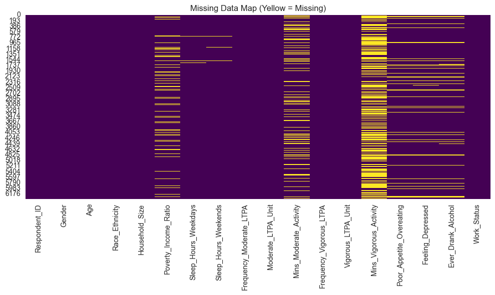

```python
sns.set_style("whitegrid")

# Missing Values Map
plt.figure(figsize=(10, 6))
sns.heatmap(df.isnull(), cbar=False, cmap='viridis')
plt.title('Missing Data Map (Yellow = Missing)')
plt.tight_layout()
plt.show()
```

### Missingness in Activity - Setting Missing to 0

```python
cols = [
    'Frequency_Moderate_LTPA',
    'Mins_Moderate_Activity',
    'Frequency_Vigorous_LTPA',
    'Mins_Vigorous_Activity'
]

df[cols] = df[cols].replace(
    {7777: 0, 9999: 0, '7777': 0, '9999': 0, '.': 0}
)

df[cols] = df[cols].fillna(0)
```

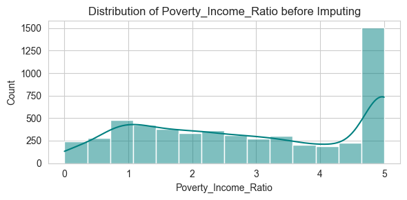

```python
num_cols = ['Poverty_Income_Ratio']

for col in num_cols:
    if col in df.columns:
        plt.figure(figsize=(6, 3))
        ax = sns.histplot(df[col].dropna(), kde=True, color='teal')
        ax.set_title(f'Distribution of {col} before Imputing')
        plt.tight_layout()
        plt.show()
```

```python
col = 'Poverty_Income_Ratio'
group_cols = ['Race_Ethnicity', 'Household_Size']

overall_non_missing = df[col].dropna().values

rng = np.random.default_rng(seed=36)

def impute_from_group_dist(g):
    mask = g[col].isna()
    if not mask.any():
        return g

    non_missing = g[col].dropna().values

    if non_missing.size == 0:
        draw_from = overall_non_missing
    else:
        draw_from = non_missing

    sampled = rng.choice(draw_from, size=mask.sum(), replace=True)
    g.loc[mask, col] = sampled
    return g

df['Poverty_Income_Ratio_imputed'] = df['Poverty_Income_Ratio']
df = (
    df
    .groupby(group_cols, group_keys=False)
    .apply(impute_from_group_dist)
)
```

```python
df = df.drop('Poverty_Income_Ratio_imputed', axis=1)
```

### Missingness in Sleep Hours

```python
df = df.dropna(subset=['Sleep_Hours_Weekdays', 'Sleep_Hours_Weekends'])
```

### Missingness in Poor Alcohol and Feeling Depressed

We decided to impute these with the median, which were 'Not at all', normal baselines for humans.

```python
cols = [
    'Poor_Appetite_Overeating',
    'Feeling_Depressed'
]

df[cols] = df[cols].fillna('Not at all')
```

### Missingness in Alcohol

In retrospect, we decided to drop the ever_drank_alcohol feature from model training. First, the variable is likely subject to systematic underreporting, especially among 18-year-olds who may be reluctant to disclose alcohol use, introducing bias rather than signal. Second, the column contains 843 missing values, which is a sizable amount of missingness relative to the sample and would require nontrivial imputation assumptions. Given these concerns about both data quality and completeness, we chose not to include this feature in future models.

# Feature Engineering

### 1. Average Daily Hours Active

### Calculation Methodology: Average Exercise Per Day

The **Avg_Exercise_Per_Day** was derived from six original columns representing two distinct categories of activity:

1. **Moderate Activity:** (`Frequency_Moderate_LTPA`, `Moderate_LTPA_Unit`, `Mins_Moderate_Activity`)
2. **Vigorous Activity:** (`Frequency_Vigorous_LTPA`, `Vigorous_LTPA_Unit`, `Mins_Vigorous_Activity`)

**The Process:**

- **Standardization:** Because respondents reported frequency in different units (Daily, Weekly, Monthly, Yearly), we used the `_Unit` columns to calculate a daily multiplication factor (e.g., Weekly = $1/7$).
- **Calculation:** We calculated the daily minutes for each category separately using the formula: `Frequency * Daily Factor * Duration`.
- **Aggregation:** The final metric is the sum of the calculated **Daily Moderate Minutes** and **Daily Vigorous Minutes**.

```python
def get_daily_minutes(row, freq_col, unit_col, min_col):
    """
    Helper function to normalize activity to minutes per day.
    """
    freq = row[freq_col]
    unit = str(row[unit_col])
    mins = row[min_col]

    # Treat missing values as 0
    if pd.isna(freq) or pd.isna(mins):
        return 0.0

    # Standardization
    if 'D' in unit:
        factor = 1.0          # Daily
    elif 'W' in unit:
        factor = 1.0 / 7.0    # Weekly
    elif 'M' in unit:
        factor = 1.0 / 30.0   # Monthly
    elif 'Y' in unit:
        factor = 1.0 / 365.0  # Yearly
    else:
        factor = 0.0

    return freq * factor * mins

# Calculate Moderate and Vigorous daily averages internally
moderate_daily = df.apply(
    lambda x: get_daily_minutes(x, 'Frequency_Moderate_LTPA', 'Moderate_LTPA_Unit', 'Mins_Moderate_Activity'),
    axis=1
)

vigorous_daily = df.apply(
    lambda x: get_daily_minutes(x, 'Frequency_Vigorous_LTPA', 'Vigorous_LTPA_Unit', 'Mins_Vigorous_Activity'),
    axis=1
)

# Create the final averaged column
df['Avg_Exercise_Per_Day'] = moderate_daily + vigorous_daily

# Define the unneeded columns to remove
columns_to_remove = [
    'Frequency_Moderate_LTPA', 'Moderate_LTPA_Unit', 'Mins_Moderate_Activity',
    'Frequency_Vigorous_LTPA', 'Vigorous_LTPA_Unit', 'Mins_Vigorous_Activity'
]

# Drop columns
df.drop(columns=columns_to_remove, inplace=True)
```

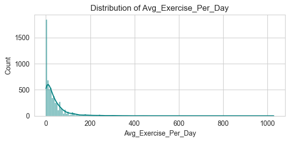

```python
num_cols = ['Avg_Exercise_Per_Day']

for col in num_cols:
    if col in df.columns:
        plt.figure(figsize=(6, 3))
        ax = sns.histplot(df[col].dropna(), kde=True, color='teal')
        ax.set_title(f'Distribution of {col}')
        plt.tight_layout()
        plt.show()
```

### 2. Average Daily Hours Slept

We will use a 7-day weighted average: $$ \text{Avg\_Sleep} = \frac{5 \cdot \text{Sleep\_Hours\_Weekdays} + 2 \cdot \text{Sleep\_Hours\_Weekends}}{7} $$

```python
df['Avg_Sleep'] = (
    5 * df['Sleep_Hours_Weekdays'] +
    2 * df['Sleep_Hours_Weekends']
) / 7
```

# 2.4 Exploratory Data Analysis

As seen below, all missing values have been dealt with, except for `Ever_Drank_Alcohol` which we will not use in our future models.

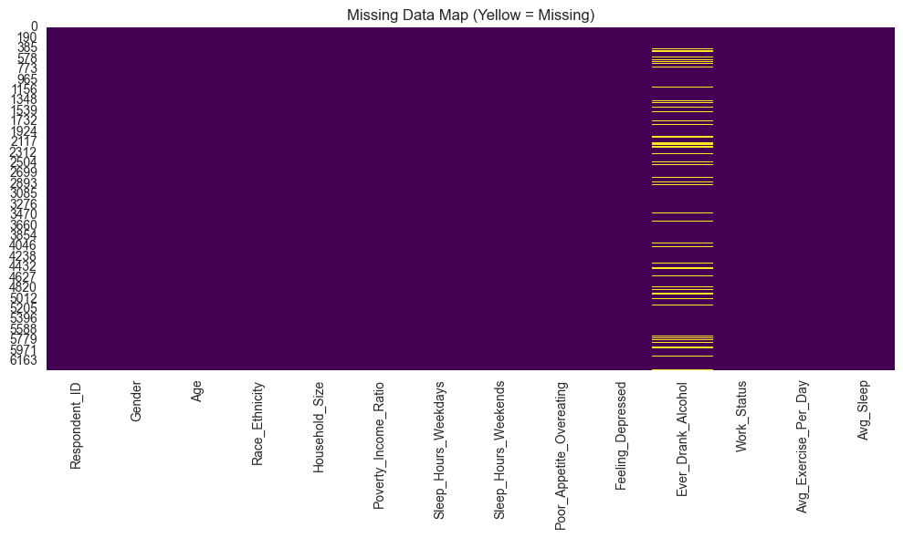

```python
# Missing Values Map
plt.figure(figsize=(10, 6))
sns.heatmap(df.isnull(), cbar=False, cmap='viridis')
plt.title('Missing Data Map (Yellow = Missing)')
plt.tight_layout()
plt.show()
```

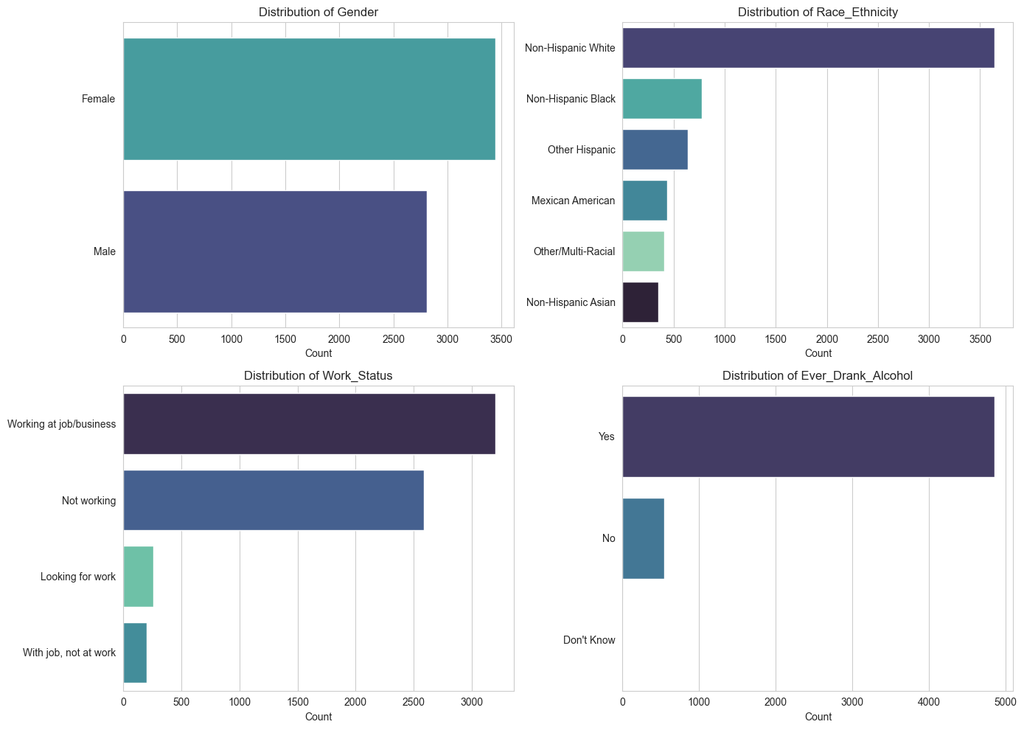

```python
cat_cols = ['Gender', 'Race_Ethnicity', 'Work_Status', 'Ever_Drank_Alcohol']
fig, axes = plt.subplots(2, 2, figsize=(14, 10))
axes = axes.flatten()

for i, col in enumerate(cat_cols):
    if col in df.columns:
        sns.countplot(
            data=df,
            y=col,
            hue=col,
            ax=axes[i],
            palette="mako",
            order=df[col].value_counts().index
        )
        leg = axes[i].get_legend()
        if leg is not None:
            leg.remove()

        axes[i].set_title(f'Distribution of {col}')
        axes[i].set_xlabel('Count')
        axes[i].set_ylabel('')

plt.tight_layout()
plt.show()
```

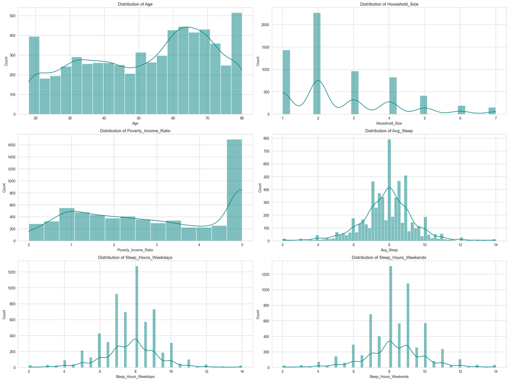

```python
# C. Numerical Distributions
num_cols = ['Age', 'Household_Size', 'Poverty_Income_Ratio', 'Avg_Sleep', 'Sleep_Hours_Weekdays','Sleep_Hours_Weekends']
fig, axes = plt.subplots(3, 2, figsize=(20, 15))
axes = axes.flatten()

for i, col in enumerate(num_cols):
    if col in df.columns:
        sns.histplot(df[col].dropna(), kde=True, ax=axes[i], color='teal')
        axes[i].set_title(f'Distribution of {col}')
plt.tight_layout()
plt.show()
```

```python
# D. Physical Activity Comparison (Boxplots)
pa_cols = ['Mins_Moderate_Activity', 'Mins_Vigorous_Activity']
if any(c in df.columns for c in pa_cols):
    plt.figure(figsize=(10, 6))

    pa_melt = df.melt(
        value_vars=[c for c in pa_cols if c in df.columns],
        var_name='Activity_Type',
        value_name='Minutes'
    )

    ax = sns.boxplot(
        x='Activity_Type',
        y='Minutes',
        data=pa_melt,
        hue='Activity_Type',
        palette='Set2'
    )

    if ax.legend_ is not None:
        ax.legend_.remove()

    plt.title('Distribution of Physical Activity Minutes')
    plt.tight_layout()
    plt.show()
```

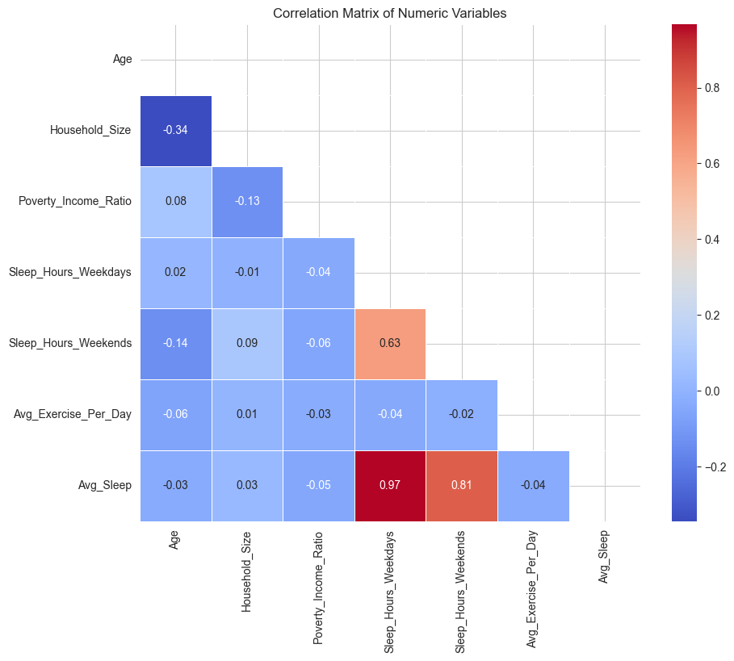

```python
# E. Correlation Heatmap (Numeric Only)
plt.figure(figsize=(10, 8))
numeric_df = df.select_dtypes(include=[np.number]).drop(columns=['Respondent_ID'], errors='ignore')
corr = numeric_df.corr()
mask = np.triu(np.ones_like(corr, dtype=bool))
sns.heatmap(corr, mask=mask, annot=True, cmap='coolwarm', fmt=".2f", linewidths=.5)
plt.title('Correlation Matrix of Numeric Variables')
plt.show()
```

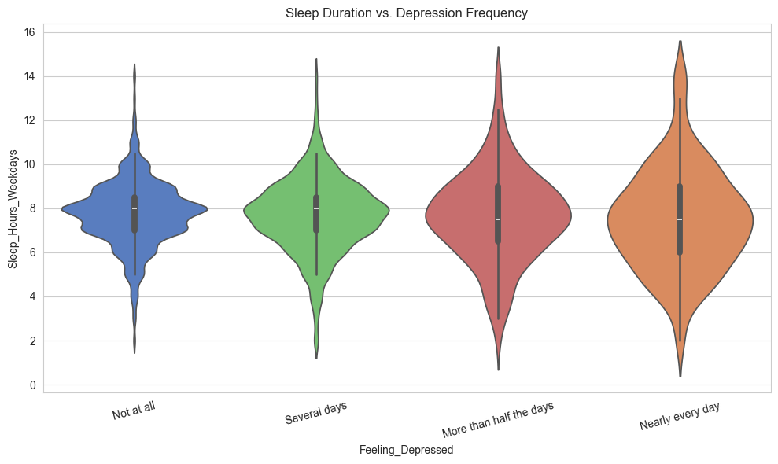

```python
# F. Sleep vs Depression
if 'Avg_Sleep' in df.columns and 'Feeling_Depressed' in df.columns:
    plt.figure(figsize=(10, 6))
    order = ['Not at all', 'Several days', 'More than half the days', 'Nearly every day']
    ax = sns.violinplot(
        data=df,
        x='Feeling_Depressed',
        y='Sleep_Hours_Weekdays',
        hue='Feeling_Depressed',
        order=order,
        palette='muted'
    )
    if ax.legend_ is not None:
        ax.legend_.remove()

    plt.title('Sleep Duration vs. Depression Frequency')
    plt.xticks(rotation=15)
    plt.tight_layout()
    plt.show()
```

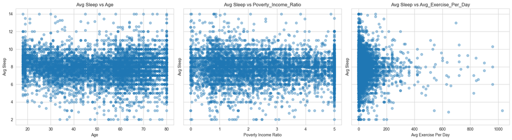

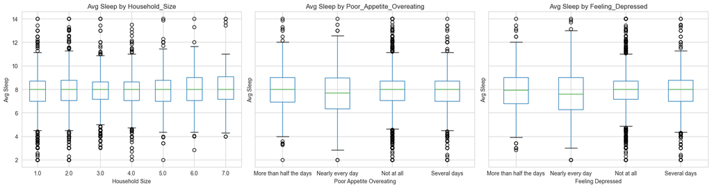

```python
scatter_cols = [
    'Age',
    'Poverty_Income_Ratio',
    'Avg_Exercise_Per_Day'
]

fig, axes = plt.subplots(1, 3, figsize=(18, 5), sharey=True)

for ax, col in zip(axes.ravel(), scatter_cols):
    ax.scatter(df[col], df['Avg_Sleep'], alpha=0.4)
    ax.set_xlabel(col.replace('_', ' '))
    ax.set_ylabel('Avg Sleep')
    ax.set_title(f'Avg Sleep vs {col}')

plt.tight_layout()
plt.show()


# --- 2. Boxplots for Household_Size, Poor_Appetite_Overeating, Feeling_Depressed ---
box_cols = [
    'Household_Size',
    'Poor_Appetite_Overeating',
    'Feeling_Depressed'
]

fig, axes = plt.subplots(1, 3, figsize=(18, 5), sharey=True)

for ax, col in zip(axes.ravel(), box_cols):
    df.boxplot(column='Avg_Sleep', by=col, ax=ax)
    ax.set_xlabel(col.replace('_', ' '))
    ax.set_ylabel('Avg Sleep')
    ax.set_title(f'Avg Sleep by {col}')

# Remove the automatic big title matplotlib adds for grouped boxplots
plt.suptitle('')
plt.tight_layout()
plt.show()
```

### Saving to CSV

```python
df.to_csv('data/data.csv', index=False)
```

A sample of the final preprocessed & cleaned dataset can be seen below:

```python
data = pd.read_csv('data/data.csv')
data.head()
```

|  | Respondent_ID | Gender | Age | Race_Ethnicity | Household_Size | Poverty_Income_Ratio | Sleep_Hours_Weekdays | Sleep_Hours_Weekends | Poor_Appetite_Overeating | Feeling_Depressed | Ever_Drank_Alcohol | Work_Status | Avg_Exercise_Per_Day | Avg_Sleep |
| --- | --- | --- | --- | --- | --- | --- | --- | --- | --- | --- | --- | --- | --- | --- |
| 0 | 130378.0 | Male | 43.0 | Non-Hispanic Asian | 4.0 | 5.00 | 9.5 | 9.0 | Not at all | Not at all | NaN | Working at job/business | 38.571429 | 9.357143 |
| 1 | 130379.0 | Male | 66.0 | Non-Hispanic White | 2.0 | 5.00 | 9.0 | 9.0 | Not at all | Not at all | Yes | Working at job/business | 45.000000 | 9.000000 |
| 2 | 130380.0 | Female | 44.0 | Other Hispanic | 7.0 | 1.41 | 8.0 | 9.0 | Not at all | Not at all | Yes | Working at job/business | 2.857143 | 8.285714 |
| 3 | 130386.0 | Male | 34.0 | Mexican American | 3.0 | 1.33 | 7.5 | 8.0 | Not at all | Not at all | Yes | Working at job/business | 5.285714 | 7.642857 |
| 4 | 130387.0 | Female | 68.0 | Non-Hispanic White | 1.0 | 1.32 | 3.0 | 5.0 | Not at all | Not at all | Yes | Not working | 0.000000 | 3.571429 |

# 3. Modeling

# 3.1 Context: How the Task Is Formulated as an ML Problem

The predictive task is formulated as a supervised regression problem. The goal is to train a model that can accurately predict a continuous numerical value—the average hours of sleep per day.

- **Inputs (Features):** The inputs to the model are a set of preprocessed demographic, behavioral, and health-related features for each individual. These include:
  - **Numerical:** `Age`, `Household_Size`, `Poverty_Income_Ratio`, `Avg_Exercise_Per_Day`
  - **Categorical (Nominal):** `Gender`, `Race_Ethnicity`, `Work_Status`
  - **Categorical (Ordinal):** `Feeling_Depressed`, `Poor_Appetite_Overeating`
- **Output (Target):** The output is a single continuous value, `Avg_Sleep`, which represents the weighted average of weekday and weekend sleep hours.
- **Optimization:** The models are trained to minimize the difference between their predicted sleep hours ((\hat{y})) and the actual sleep hours ((y)). This is achieved by optimizing for specific metrics during training and hyperparameter tuning. In this project, `GridSearchCV` is configured to maximize the (R^2) score, effectively finding the model parameters that explain the most variance in the target variable. We also track Mean Absolute Error (MAE) and Mean Squared Error (MSE) to evaluate the model's predictive accuracy.
- **Appropriate Models:** For this regression task, a range of models is appropriate to explore the complexity of the data:
  1. **Linear Models:** (Ridge, Lasso, ElasticNet) to establish a strong, interpretable baseline.
  2. **Tree-based Ensembles:** (Random Forest, Gradient Boosting) to capture non-linear relationships and feature interactions.
  3. **Other Non-linear Models:** (Support Vector Regressor, K-Nearest Neighbors) to explore different modeling paradigms.
  4. **Neural Networks:** (Multi-layer Perceptron) to attempt to capture highly complex patterns, if they exist.

# 3.2 Discussion: Advantages and Disadvantages of Modeling Approaches

Different modeling approaches offer trade-offs between performance, interpretability, and computational complexity.

#### 1. Linear Models (Ridge, Lasso, ElasticNet)

- **Advantages:**
  - **High interpretability:** The model coefficients directly indicate the weight and direction (positive/negative) of each feature's influence on sleep, making them easy to understand.
  - **Efficiency:** They are computationally fast to train and require less memory.
  - **Strong baseline:** They provide a robust and difficult-to-beat baseline. If complex models cannot outperform them, it suggests the relationships in the data are primarily linear.
- **Disadvantages:**
  - **Linearity assumption:** Their primary limitation is the assumption that the relationship between features and sleep is linear. This is likely an oversimplification for complex biopsychosocial phenomena.
  - **Limited predictive power:** If the true relationships are non-linear, these models may have lower predictive accuracy compared to more complex alternatives.

#### 2. Tree-based Ensemble Models (Random Forest, Gradient Boosting)

- **Advantages:**
  - **Capture non-linearity:** They are excellent at modeling complex, non-linear relationships and feature interactions without requiring explicit feature engineering.
  - **High performance:** These models are frequently among the top performers in regression tasks on tabular data.
  - **Robustness:** They are less sensitive to feature scaling and can handle a mix of numerical and categorical data well. They also provide feature importance rankings, offering some insight into the model's decisions.
- **Disadvantages:**
  - **Reduced interpretability:** While we can see which features are important, it's difficult to understand precisely how they influence the prediction (e.g., the specific thresholds or interactions). They are often considered “black boxes.”
  - **Computational cost:** Training can be slow, especially with a large number of trees or deep trees. They also require more memory.
  - **Prone to overfitting:** They can easily overfit the training data if hyperparameters (like `max_depth` or `n_estimators`) are not carefully tuned.

#### 3. Support Vector Regressor (SVR)

- **Advantages:**
  - **Effective in high dimensions:** Can perform well even with a large number of features.
  - **Non-linear capability:** Using kernels (like the RBF kernel), SVR can effectively model complex, non-linear relationships.
- **Disadvantages:**
  - **Lack of interpretability:** It is very difficult to interpret the model's decision-making process.
  - **Sensitivity to hyperparameters:** Performance is highly dependent on the choice of (C), (\epsilon), and kernel parameters (e.g., (\gamma)), making hyperparameter tuning crucial and sometimes challenging.
  - **Training time:** Can be slow to train on larger datasets.

#### 4. Neural Network (MLP)

- **Advantages:**
  - **Maximum flexibility:** Can approximate any continuous function, giving it the potential to capture very complex patterns in the data.
- **Disadvantages:**
  - **Highest complexity:** The “black box” nature makes it the least interpretable model.
  - **Data-hungry:** Requires a substantial amount of data to train effectively and avoid overfitting. For a dataset of this size (~6,000 samples), it might not outperform simpler models.
  - **Sensitive to tuning:** Performance is highly sensitive to architecture (number of layers/neurons), learning rate, and feature scaling, making it difficult and time-consuming to optimize. As seen in our baseline results, a poorly tuned MLP performs very poorly.

# 3.3.1 Baseline Models

The code in the cell below preprocesses data and then trains and evaluates a wide range of regression models. The key architectural choices are designed for robustness, scalability, and the prevention of common machine learning pitfalls like data leakage.

### 1. Preprocessing with `ColumnTransformer`

The most important architectural choice is the use of `sklearn.compose.ColumnTransformer`. The dataset contains a mix of numerical, ordinal (ordered categorical), and nominal (unordered categorical) features, each requiring a different preprocessing strategy.

- **Why it was chosen:** Instead of manually transforming columns and tracking them in separate DataFrames, `ColumnTransformer` provides a single, organized object to define these steps.
- **Implementation Details:**
  - **Numerical Features (`numeric_feats`):** These are scaled using `StandardScaler`. This is needed for models sensitive to feature scale, such as SVR, k-NN, and regularized linear models, ensuring that no single feature dominates due to its large magnitude.
  - **Ordinal Features (`ordinal_feats`):** Features like `Feeling_Depressed` have a clear order. `OrdinalEncoder` is used to convert these categories into numerical rankings (e.g., `"Not at all" → 0`, `"Several days" → 1`). This preserves the inherent order, which is valuable information for the model. We explicitly define the categories to guarantee the encoding order is correct.
  - **Nominal Features (`nominal_feats`):** Features like `Gender` or `Race_Ethnicity` have no intrinsic order. `OneHotEncoder` is used to convert them into a series of binary columns, preventing the model from incorrectly assuming a ranked relationship between them.

### 2. Preventing Data Leakage with `Pipeline`

All preprocessing steps and the final model are bundled together into a `sklearn.pipeline.Pipeline`.

- **Why it was chosen:** This is the most important step for ensuring model validity. A `Pipeline` encapsulates the entire workflow, from preprocessing to prediction. When the pipeline is trained, the `ColumnTransformer` is fit only on the training data to learn the scaling parameters and encodings. It then transforms both the training and test data using these learned parameters. This prevents information from the test set from leaking into the training process, which would lead to an overly optimistic and invalid evaluation.
- **Implementation Details:** The pipeline consists of two steps: `("preprocessor", preprocessor)` and `("model", base_model)`. This allows us to treat the entire sequence as a single estimator, which simplifies fitting, prediction, and hyperparameter tuning.

### 3. Model Benchmarking Loop

To efficiently compare a wide array of models, the code iterates through a `models` dictionary.

- **Why it was chosen:** This architecture is highly scalable and avoids code duplication. It allows us to easily add, remove, or modify models for experimentation.
- **Implementation Details:**
  - A dictionary `models` holds the different model instances we want to evaluate.
  - A `for` loop iterates through this dictionary, and for each model, it:
    1. Builds a unique `Pipeline`.
    2. Fits the pipeline on the training data.
    3. Makes predictions on the unseen test data.
    4. Computes and prints standard regression metrics (MAE, MSE, (R^2)).
    5. Appends the results to a list, which is then converted to a DataFrame for a final, sorted comparison.

```python
from sklearn.model_selection import train_test_split, GridSearchCV
from sklearn.linear_model import Ridge, Lasso, ElasticNet
from sklearn.ensemble import RandomForestRegressor, HistGradientBoostingRegressor, GradientBoostingRegressor, ExtraTreesRegressor
from sklearn.svm import SVR
from sklearn.neighbors import KNeighborsRegressor
from sklearn.neural_network import MLPRegressor
from sklearn.preprocessing import OneHotEncoder, StandardScaler, OrdinalEncoder
from sklearn.compose import ColumnTransformer
from sklearn.pipeline import Pipeline
from sklearn.metrics import mean_absolute_error, mean_squared_error, r2_score

# =========================
# Load & basic preprocessing
# =========================
df = pd.read_csv('data/data.csv')

feature_cols = [
    'Gender', 'Age', 'Race_Ethnicity', 'Household_Size', 'Poverty_Income_Ratio',
    'Poor_Appetite_Overeating', 'Feeling_Depressed', 'Work_Status', 'Avg_Exercise_Per_Day'
]
target_col = 'Avg_Sleep'

X = df[feature_cols].copy()
y = df[target_col].copy()

# Take care of any possible errors, after formal preprocessing
for col in X.select_dtypes(include='object').columns:
    X[col] = X[col].fillna("Unknown")
for col in X.select_dtypes(include=['float64', 'int64']).columns:
    X[col] = X[col].fillna(X[col].median())

# =========================
# Column types & encoders
# =========================
ordinal_feats = ['Poor_Appetite_Overeating', 'Feeling_Depressed']
ordinal_order = [['Not at all', 'Several days', 'More than half the days', 'Nearly every day']] * 2

nominal_feats = ['Gender', 'Race_Ethnicity', 'Work_Status']

numeric_feats = ['Age', 'Household_Size', 'Poverty_Income_Ratio']

preprocessor = ColumnTransformer(
    transformers=[
        ('num', StandardScaler(), numeric_feats),
        ('ord', OrdinalEncoder(categories=ordinal_order,
                               handle_unknown='use_encoded_value',
                               unknown_value=-1),
         ordinal_feats),
        ('nom', OneHotEncoder(handle_unknown='ignore', sparse_output=False), nominal_feats)
    ])

X_train, X_test, y_train, y_test = train_test_split(
    X, y, test_size=0.2, random_state=36
)

# =========================
# Base Models
# =========================
models = {
    "Ridge (L2 Penalty)": Ridge(alpha=1.0),
    "Lasso (L1 Penalty)": Lasso(alpha=0.01),
    "ElasticNet": ElasticNet(alpha=0.01, l1_ratio=0.5),
    "SVR (RBF Kernel)": SVR(C=1.0, epsilon=0.1),
    "K-Nearest Neighbors": KNeighborsRegressor(n_neighbors=10),
    "Random Forest": RandomForestRegressor(n_estimators=100, max_depth=10, random_state=36),
    "Extra Trees": ExtraTreesRegressor(n_estimators=100, max_depth=10, random_state=36),
    "Gradient Boosting": GradientBoostingRegressor(n_estimators=100, max_depth=3, random_state=36),
    "Hist Gradient Boosting": HistGradientBoostingRegressor(random_state=36),
    "Neural Network (MLP)": MLPRegressor(hidden_layer_sizes=(64, 32), max_iter=1000, random_state=36)
}

# =========================
# Parameter grids for grid search
# =========================
param_grids = {
# For baseline models, we will not be performing a grid search
}

results = []

print(f"{'Model':<30} | {'MAE':<10} | {'MSE':<10} | {'R2 Score':<10}")
print("-" * 70)

for name, base_model in models.items():
    # Building the pipeline
    pipe = Pipeline(steps=[('preprocessor', preprocessor),
                           ('model', base_model)])

    if name in param_grids:
        print(f"\nRunning GridSearchCV for: {name}")
        grid = GridSearchCV(
            pipe,
            param_grid=param_grids[name],
            cv=5,
            scoring='r2',
            n_jobs=-1,
            verbose=1
        )
        grid.fit(X_train, y_train)
        best_model = grid.best_estimator_

        print(f"Best params for {name}: {grid.best_params_}")
        print(f"Best CV R2 for {name}: {grid.best_score_:.4f}")

        # Use the tuned model for test evaluation
        y_pred = best_model.predict(X_test)
        used_model = best_model
    else:
        # No grid search
        pipe.fit(X_train, y_train)
        y_pred = pipe.predict(X_test)
        used_model = pipe

    # Evaluate on test set
    mae = mean_absolute_error(y_test, y_pred)
    mse = mean_squared_error(y_test, y_pred)
    r2  = r2_score(y_test, y_pred)

    results.append({
        'Model': name,
        'MAE': mae,
        'MSE': mse,
        'R2': r2
    })

    print(f"{name:<30} | {mae:<10.4f} | {mse:<10.4f} | {r2:<10.4f}")

results_df = pd.DataFrame(results).sort_values(by="R2", ascending=False)
print("\nSorted results by R2:")
print(results_df)
```

```
Model                          | MAE        | MSE        | R2 Score
----------------------------------------------------------------------
Ridge (L2 Penalty)             | 1.0614     | 2.1069     | 0.0239
Lasso (L1 Penalty)             | 1.0569     | 2.1019     | 0.0263
ElasticNet                     | 1.0576     | 2.1001     | 0.0271
SVR (RBF Kernel)               | 1.0751     | 2.1677     | -0.0042
K-Nearest Neighbors            | 1.1062     | 2.2974     | -0.0643
Random Forest                  | 1.0590     | 2.1207     | 0.0176
Extra Trees                    | 1.0713     | 2.1679     | -0.0043
Gradient Boosting              | 1.0631     | 2.1197     | 0.0180
Hist Gradient Boosting         | 1.0840     | 2.1880     | -0.0136
Neural Network (MLP)           | 1.2038     | 2.7360     | -0.2675

Sorted results by R2:
                    Model       MAE       MSE        R2
2              ElasticNet  1.057574  2.100149  0.027078
1      Lasso (L1 Penalty)  1.056873  2.101891  0.026271
0      Ridge (L2 Penalty)  1.061361  2.106902  0.023950
7       Gradient Boosting  1.063089  2.119689  0.018026
5           Random Forest  1.059031  2.120711  0.017553
3        SVR (RBF Kernel)  1.075076  2.167657 -0.004195
6             Extra Trees  1.071329  2.167928 -0.004321
8  Hist Gradient Boosting  1.083963  2.188006 -0.013622
4     K-Nearest Neighbors  1.106223  2.297446 -0.064322
9    Neural Network (MLP)  1.203827  2.735962 -0.267470
```

# 3.3.2 Improved Baseline Models

The code in the cell below enhances the initial modeling framework by integrating `GridSearchCV` to systematically find the best-performing version of each model. The core architecture of using `ColumnTransformer` and `Pipeline` remains the same for robustness and to prevent data leakage.

### 1. Comprehensive Hyperparameter Grids (`param_grids`)

- **Why it was chosen:** The performance of most machine learning models is highly sensitive to their hyperparameters (e.g., `learning_rate` for Gradient Boosting, `C` for SVR, or `max_depth` for Random Forest). Manually tuning these is impractical. Defining a grid of options for each allows us to automate the search for the optimal combination.
- **Implementation Details:**
  - Each key in `param_grids` corresponds to a model in the `models` dictionary.
  - The values are dictionaries where keys are the parameter names (using the `model__` prefix to specify they belong to the `"model"` step of our pipeline) and values are lists of settings to try. For example, for *Random Forest*, we explore various numbers of trees (`n_estimators`), tree depths (`max_depth`), and other structural parameters to find the best balance between model complexity and generalization.

### 2. Automated Tuning and Cross-Validation with `GridSearchCV`

The core of the improvement is replacing the simple `.fit()` call from the previous script with `GridSearchCV`.

- **Why it was chosen:** `GridSearchCV` provides a robust and exhaustive method for hyperparameter tuning:
  1. **Exhaustive search:** It tries every possible combination of parameters defined in the `param_grid`.
  2. **Robust evaluation:** For each combination, it performs k-fold cross-validation (`cv=5`). This means it splits the training data into 5 folds, trains on 4, and evaluates on the 5th, repeating this 5 times. The reported performance for that parameter set is the average across all 5 folds. This process gives a much more reliable estimate of how the model will perform on unseen data and prevents us from getting “lucky” with a single train/validation split.
- **Implementation Details:**
  - **`pipe` as the estimator:** We pass the entire `Pipeline` object to `GridSearchCV`. This is a critical architectural choice, as it ensures that our preprocessing steps are correctly applied within each cross-validation fold, preventing data leakage from the validation part of the fold into the training part.
  - **`scoring="r2"`:** We explicitly tell `GridSearchCV` to find the parameter combination that maximizes the (R^2) score, our chosen optimization metric.
  - **`n_jobs=-1`:** This is a crucial detail for efficiency. It instructs `GridSearchCV` to use all available CPU cores to run the training jobs in parallel, dramatically speeding up the computationally expensive search process.
  - **`best_model = grid.best_estimator_`:** After the grid search completes, the `.best_estimator_` attribute contains a new pipeline that has been automatically retrained on the entire training set using the best-found hyperparameters. This is the final, tuned model that we use for evaluation.

By integrating `GridSearchCV` into the existing `Pipeline` framework, this code automates the process of finding a well-tuned, high-performing version of each model in a robust and computationally efficient manner, leading to more reliable and improved baseline results.

```python
import warnings
from sklearn.exceptions import ConvergenceWarning

warnings.filterwarnings("ignore", category=ConvergenceWarning)
warnings.filterwarnings("ignore", category=UserWarning)

# =========================
# Load & basic preprocessing
# =========================
df = pd.read_csv('data/data.csv')

feature_cols = [
    'Gender', 'Age', 'Race_Ethnicity', 'Household_Size', 'Poverty_Income_Ratio',
    'Poor_Appetite_Overeating', 'Feeling_Depressed', 'Work_Status', 'Avg_Exercise_Per_Day'
]
target_col = 'Avg_Sleep'

X = df[feature_cols].copy()
y = df[target_col].copy()

for col in X.select_dtypes(include='object').columns:
    X[col] = X[col].fillna("Unknown")
for col in X.select_dtypes(include=['float64', 'int64']).columns:
    X[col] = X[col].fillna(X[col].median())

# =========================
# Column types & encoders
# =========================
ordinal_feats = ['Poor_Appetite_Overeating', 'Feeling_Depressed']
ordinal_order = [['Not at all', 'Several days',
                  'More than half the days', 'Nearly every day']] * 2

nominal_feats = ['Gender', 'Race_Ethnicity', 'Work_Status']

numeric_feats = ['Age', 'Household_Size', 'Poverty_Income_Ratio']

preprocessor = ColumnTransformer(
    transformers=[
        ('num', StandardScaler(), numeric_feats),
        ('ord', OrdinalEncoder(categories=ordinal_order,
                               handle_unknown='use_encoded_value',
                               unknown_value=-1),
         ordinal_feats),
        ('nom', OneHotEncoder(handle_unknown='ignore', sparse_output=False),
         nominal_feats)
    ]
)

X_train, X_test, y_train, y_test = train_test_split(
    X, y, test_size=0.2, random_state=36
)

# =========================
# Improved Baseline Models
# =========================
models = {
    "Ridge (L2 Penalty)": Ridge(),
    "Lasso (L1 Penalty)": Lasso(),
    "ElasticNet": ElasticNet(),
    "SVR (RBF Kernel)": SVR(),
    "K-Nearest Neighbors": KNeighborsRegressor(),
    "Random Forest": RandomForestRegressor(random_state=36),
    "Extra Trees": ExtraTreesRegressor(random_state=36),
    "Gradient Boosting": GradientBoostingRegressor(random_state=36),
    "Hist Gradient Boosting": HistGradientBoostingRegressor(random_state=36),
    "Neural Network (MLP)": MLPRegressor(max_iter=1000, random_state=36)
}

# =========================
# Hyperparameter grids - Now defined
# =========================
param_grids = {
    "Ridge (L2 Penalty)": {
        "model__alpha": [0.01, 0.1, 1.0, 10.0, 100.0]
    },
    "Lasso (L1 Penalty)": {
        "model__alpha": [1e-4, 1e-3, 1e-2, 1e-1, 1, 10],
        "model__max_iter": [1000, 5000, 10000]
    },
    "ElasticNet": {
        "model__alpha": [1e-4, 1e-3, 1e-2, 1e-1, 1, 10],
        "model__l1_ratio": [0.1, 0.3, 0.5, 0.7, 0.9],
        "model__max_iter": [1000, 5000, 10000]
    },
    "SVR (RBF Kernel)": {
        "model__C": [0.1, 1, 10, 100],
        "model__epsilon": [0.01, 0.1, 0.5],
        "model__gamma": ["scale", "auto"]
    },
    "K-Nearest Neighbors": {
        "model__n_neighbors": [3, 5, 10, 20],
        "model__weights": ["uniform", "distance"],
        "model__p": [1, 2]  # Manhattan vs Euclidean
    },
    "Random Forest": {
        "model__n_estimators": [100, 300, 500],
        "model__max_depth": [None, 5, 10, 20],
        "model__min_samples_split": [2, 5, 10],
        "model__min_samples_leaf": [1, 2, 4],
        "model__max_features": ["sqrt", "log2", 0.5]
    },
    "Extra Trees": {
        "model__n_estimators": [100, 300, 500],
        "model__max_depth": [None, 5, 10, 20],
        "model__min_samples_split": [2, 5, 10],
        "model__min_samples_leaf": [1, 2, 4],
        "model__max_features": ["sqrt", "log2", 0.5]
    },
    "Gradient Boosting": {
        "model__n_estimators": [100, 200, 300],
        "model__learning_rate": [0.01, 0.05, 0.1],
        "model__max_depth": [2, 3, 4],
        "model__subsample": [0.8, 1.0]
    },
    "Hist Gradient Boosting": {
        "model__learning_rate": [0.01, 0.05, 0.1],
        "model__max_depth": [None, 5, 10],
        "model__max_leaf_nodes": [31, 63, 127],
        "model__min_samples_leaf": [20, 50, 100]
    },
    "Neural Network (MLP)": {
        "model__hidden_layer_sizes": [(64, 32), (128, 64), (128, 64, 32)],
        "model__activation": ["relu", "tanh"],
        "model__alpha": [1e-5, 1e-4, 1e-3],
        "model__learning_rate_init": [0.001, 0.01]
    }
}

# =========================
# Grid search
# =========================
results = []

print(f"{'Model':<30} | {'MAE':<10} | {'MSE':<10} | {'R2 Score':<10}")
print("-" * 70)

for name, model in models.items():
    print(f"\nTuning {name}...")
    pipe = Pipeline(steps=[
        ("preprocessor", preprocessor),
        ("model", model)
    ])

    grid = GridSearchCV(
        pipe,
        param_grid=param_grids[name],
        cv=5,
        scoring="r2",
        n_jobs=-1,
        verbose=1
    )

    grid.fit(X_train, y_train)

    best_model = grid.best_estimator_
    y_pred = best_model.predict(X_test)

    mae = mean_absolute_error(y_test, y_pred)
    mse = mean_squared_error(y_test, y_pred)
    r2 = r2_score(y_test, y_pred)

    results.append({
        "Model": name,
        "Best Params": grid.best_params_,
        "CV Best R2": grid.best_score_,
        "MAE": mae,
        "MSE": mse,
        "R2": r2
    })

    print(f"Best params: {grid.best_params_}")
    print(f"Best CV R2: {grid.best_score_:.4f}")
    print(f"{name:<30} | {mae:<10.4f} | {mse:<10.4f} | {r2:<10.4f}")

results_df_2 = pd.DataFrame(results)
results_df_sorted = results_df_2.sort_values(by="R2", ascending=False)
print("\nSorted results by test R2:")
print(results_df_sorted[["Model", "R2", "MAE", "MSE"]])
```

```
Model                          | MAE        | MSE        | R2 Score
----------------------------------------------------------------------

Tuning Ridge (L2 Penalty)...
Fitting 5 folds for each of 5 candidates, totalling 25 fits
Best params: {'model__alpha': 100.0}
Best CV R2: 0.0211
Ridge (L2 Penalty)             | 1.0598     | 2.1040     | 0.0253

Tuning Lasso (L1 Penalty)...
Fitting 5 folds for each of 18 candidates, totalling 90 fits
Best params: {'model__alpha': 0.001, 'model__max_iter': 1000}
Best CV R2: 0.0199
Lasso (L1 Penalty)             | 1.0605     | 2.1049     | 0.0249

Tuning ElasticNet...
Fitting 5 folds for each of 90 candidates, totalling 450 fits
Best params: {'model__alpha': 0.01, 'model__l1_ratio': 0.1, 'model__max_iter': 1000}
Best CV R2: 0.0205
ElasticNet                     | 1.0598     | 2.1037     | 0.0254

Tuning SVR (RBF Kernel)...
Fitting 5 folds for each of 24 candidates, totalling 120 fits
Best params: {'model__C': 0.1, 'model__epsilon': 0.01, 'model__gamma': 'auto'}
Best CV R2: 0.0263
SVR (RBF Kernel)               | 1.0509     | 2.0870     | 0.0332

Tuning K-Nearest Neighbors...
Fitting 5 folds for each of 16 candidates, totalling 80 fits
Best params: {'model__n_neighbors': 20, 'model__p': 2, 'model__weights': 'uniform'}
Best CV R2: -0.0164
K-Nearest Neighbors            | 1.0912     | 2.2198     | -0.0284

Tuning Random Forest...
Fitting 5 folds for each of 324 candidates, totalling 1620 fits
Best params: {'model__max_depth': 5, 'model__max_features': 'sqrt', 'model__min_samples_leaf': 4, 'model__min_samples_split': 10, 'model__n_estimators': 100}
Best CV R2: 0.0235
Random Forest                  | 1.0536     | 2.0893     | 0.0321

Tuning Extra Trees...
```

[output cut: 20 more lines]

```
Best CV R2: -0.0037
Neural Network (MLP)           | 1.0663     | 2.1688     | -0.0047

Sorted results by test R2:
                    Model        R2       MAE       MSE
7       Gradient Boosting  0.037534  1.048020  2.077580
3        SVR (RBF Kernel)  0.033151  1.050917  2.087041
5           Random Forest  0.032105  1.053567  2.089299
6             Extra Trees  0.029044  1.056324  2.095905
8  Hist Gradient Boosting  0.028888  1.054831  2.096244
2              ElasticNet  0.025428  1.059818  2.103711
0      Ridge (L2 Penalty)  0.025300  1.059821  2.103988
1      Lasso (L1 Penalty)  0.024870  1.060502  2.104916
9    Neural Network (MLP) -0.004722  1.066331  2.168794
4     K-Nearest Neighbors -0.028371  1.091160  2.219841
```

### Sample Sleep Predictions for Typical Profiles

[output not shown]

For each of these profiles, the model predicts an `Avg_Sleep` (hours of sleep per day). The full set of profiles and model predictions is stored in the CSV file `sample_sleep_predictions_gb.csv` generated by the code below.

```python
# =========================
# 1. Rebuild the best Gradient Boosting model
#    (using the best hyperparameters)
# =========================

best_gb_model = GradientBoostingRegressor(
    learning_rate=0.01,
    max_depth=2,
    n_estimators=300,
    subsample=0.8,
    random_state=36
)

best_gb_pipeline = Pipeline(steps=[
    ("preprocessor", preprocessor),
    ("model", best_gb_model)
])

# Fit on ALL available data
best_gb_pipeline.fit(X, y)

# =========================
# 2. Define sample "stereotypical" profiles
# =========================

sample_profiles = pd.DataFrame([
    {
        # 1. Fit working man in good mental health
        "Gender": "Male",
        "Age": 35,
        "Race_Ethnicity": "Non-Hispanic White",
        "Household_Size": 2,
        "Poverty_Income_Ratio": 4.5,
        "Poor_Appetite_Overeating": "Not at all",
        "Feeling_Depressed": "Not at all",
        "Work_Status": "Working at job/business",
        "Avg_Exercise_Per_Day": 60.0
    },
    {
        # 2. Busy working woman with some stress
        "Gender": "Female",
        "Age": 40,
        "Race_Ethnicity": "Non-Hispanic Black",
        "Household_Size": 4,
        "Poverty_Income_Ratio": 3.0,
        "Poor_Appetite_Overeating": "Several days",
        "Feeling_Depressed": "Several days",
        "Work_Status": "Working at job/business",
        "Avg_Exercise_Per_Day": 25.0
    },
    {
        # 3. Older retired adult, low activity but emotionally well
        "Gender": "Male",
        "Age": 70,
        "Race_Ethnicity": "Mexican American",
        "Household_Size": 1,
        "Poverty_Income_Ratio": 2.0,
        "Poor_Appetite_Overeating": "Not at all",
        "Feeling_Depressed": "Not at all",
        "Work_Status": "Not working",
        "Avg_Exercise_Per_Day": 5.0
    },
    {
        # 4. Young unemployed adult with frequent depression and poor appetite
        "Gender": "Female",
        "Age": 25,
        "Race_Ethnicity": "Other Hispanic",
        "Household_Size": 3,
        "Poverty_Income_Ratio": 1.3,
        "Poor_Appetite_Overeating": "Nearly every day",
        "Feeling_Depressed": "Nearly every day",
        "Work_Status": "Not working",
        "Avg_Exercise_Per_Day": 0.0
    },
    {
        # 5. Middle-aged sedentary worker, often depressed
        "Gender": "Male",
        "Age": 50,
        "Race_Ethnicity": "Non-Hispanic Asian",
        "Household_Size": 3,
        "Poverty_Income_Ratio": 2.2,
        "Poor_Appetite_Overeating": "More than half the days",
        "Feeling_Depressed": "More than half the days",
        "Work_Status": "Working at job/business",
        "Avg_Exercise_Per_Day": 5.0
    },
    {
        # 6. Active worker with occasional low mood
        "Gender": "Female",
        "Age": 30,
        "Race_Ethnicity": "Non-Hispanic White",
        "Household_Size": 2,
        "Poverty_Income_Ratio": 3.5,
        "Poor_Appetite_Overeating": "Several days",
        "Feeling_Depressed": "Several days",
        "Work_Status": "Working at job/business",
        "Avg_Exercise_Per_Day": 45.0
    }
])

# =========================
# 3. Generate predictions
# =========================

predicted_sleep = best_gb_pipeline.predict(sample_profiles)

sample_profiles_with_preds = sample_profiles.copy()
sample_profiles_with_preds["Predicted_Avg_Sleep"] = predicted_sleep

print("Sample predictions (Avg_Sleep in hours/day):")
print(sample_profiles_with_preds)

output_path = "sample_sleep_predictions_gb.csv"
sample_profiles_with_preds.to_csv(output_path, index=False)

print(f"\nSaved sample predictions to: {output_path}")
```

```
Sample predictions (Avg_Sleep in hours/day):
   Gender  Age      Race_Ethnicity  Household_Size  Poverty_Income_Ratio  \
0    Male   35  Non-Hispanic White               2                   4.5
1  Female   40  Non-Hispanic Black               4                   3.0
2    Male   70    Mexican American               1                   2.0
3  Female   25      Other Hispanic               3                   1.3
4    Male   50  Non-Hispanic Asian               3                   2.2
5  Female   30  Non-Hispanic White               2                   3.5

  Poor_Appetite_Overeating        Feeling_Depressed              Work_Status  \
0               Not at all               Not at all  Working at job/business
1             Several days             Several days  Working at job/business
2               Not at all               Not at all              Not working
3         Nearly every day         Nearly every day              Not working
4  More than half the days  More than half the days  Working at job/business
5             Several days             Several days  Working at job/business

   Avg_Exercise_Per_Day  Predicted_Avg_Sleep
0                  60.0             7.676503
1                  25.0             7.654296
2                   5.0             7.876350
3                   0.0             8.053508
4                   5.0             7.565609
5                  45.0             7.938384

Saved sample predictions to: sample_sleep_predictions_gb.csv
```

# 4. Evaluation

# 4.1 Context: How the Task Is Evaluated

This is a regression task, so we evaluate our models based on how close their predictions are to the true values. We use a suite of standard regression metrics, each offering a different perspective on performance.

- **Mean Absolute Error (MAE):** This is our primary metric for interpretability. It measures the average absolute difference between the predicted and actual sleep hours. For example, an MAE of 1.05 means our model's predictions are, on average, off by about 1 hour. This is easy to understand and communicate.
- **Mean Squared Error (MSE):** This metric squares the errors before averaging them, which penalizes larger errors more heavily than smaller ones. While less interpretable directly, it is a common loss function for model optimization.
- **R-squared ((R^2)) Score:** This metric is crucial for understanding the model's explanatory power. It measures the proportion of the variance in `Avg_Sleep` that is predictable from our features. An (R^2) of 1.0 would mean the model perfectly explains the variance, while an (R^2) of 0.0 means the model is no better than a naive baseline that simply predicts the average sleep time for everyone. A negative (R^2) indicates the model is actively worse than this naive baseline. In a complex problem like predicting human behavior, even a small positive (R^2) can be a meaningful signal, indicating that the features, while not explaining everything, do have some predictive power.

# 4.2 Discussion: Baselines and Demonstrating Improvement

To demonstrate that our modeling approach is effective, we compare its performance against a hierarchy of baselines.

**Demonstrating Improvement:** We demonstrate that our method is better in two ways:

- First, we show that our best-tuned models achieve a positive (R^2) score, indicating they outperform the trivial mean-prediction baseline.
- Second, by comparing the performance tables of the untuned versus the tuned models, we show that the hyperparameter tuning process (`GridSearchCV`) consistently provides a small but significant lift in performance for most models. For instance, the untuned Gradient Boosting model had an (R^2) of 0.018, while the tuned version improved to 0.038, more than doubling its explanatory power. The final, best-performing model from this analysis is the tuned Gradient Boosting Regressor, which had the highest (R^2) score on the unseen test set.

```python
print("Baseline Models: Sorted results by R2:")
print(results_df)
```

```
Baseline Models: Sorted results by R2:
                    Model       MAE       MSE        R2
2              ElasticNet  1.057574  2.100149  0.027078
1      Lasso (L1 Penalty)  1.056873  2.101891  0.026271
0      Ridge (L2 Penalty)  1.061361  2.106902  0.023950
7       Gradient Boosting  1.063089  2.119689  0.018026
5           Random Forest  1.059031  2.120711  0.017553
3        SVR (RBF Kernel)  1.075076  2.167657 -0.004195
6             Extra Trees  1.071329  2.167928 -0.004321
8  Hist Gradient Boosting  1.083963  2.188006 -0.013622
4     K-Nearest Neighbors  1.106223  2.297446 -0.064322
9    Neural Network (MLP)  1.203827  2.735962 -0.267470
```

```python
print("Improved Baseline Models: Sorted results by test R2:")
print(results_df_sorted[["Model", "MAE", "MSE", "R2"]])
```

```
Improved Baseline Models: Sorted results by test R2:
                    Model       MAE       MSE        R2
7       Gradient Boosting  1.048020  2.077580  0.037534
3        SVR (RBF Kernel)  1.050917  2.087041  0.033151
5           Random Forest  1.053567  2.089299  0.032105
6             Extra Trees  1.056324  2.095905  0.029044
8  Hist Gradient Boosting  1.054831  2.096244  0.028888
2              ElasticNet  1.059818  2.103711  0.025428
0      Ridge (L2 Penalty)  1.059821  2.103988  0.025300
1      Lasso (L1 Penalty)  1.060502  2.104916  0.024870
9    Neural Network (MLP)  1.066331  2.168794 -0.004722
4     K-Nearest Neighbors  1.091160  2.219841 -0.028371
```

This analysis compares the results from the initial “out-of-the-box” models against the same models after undergoing a rigorous hyperparameter tuning process using `GridSearchCV`.

## Detailed Performance Comparison

Below is a model-by-model comparison of baseline vs. tuned performance:

| Model | Metric | Baseline | Improved | Absolute Change | % Change |
| --- | --- | --- | --- | --- | --- |
| **Gradient Boosting** | R² | 0.0180 | 0.0375 | +0.0195 | +108.3% |
|  | MAE | 1.0631 | 1.0480 | -0.0151 | -1.4% |
|  | MSE | 2.1197 | 2.0776 | -0.0421 | -2.0% |
| **SVR (RBF Kernel)** | R² | -0.0042 | 0.0332 | +0.0374 | N/A |
|  | MAE | 1.0751 | 1.0509 | -0.0242 | -2.3% |
|  | MSE | 2.1677 | 2.0870 | -0.0807 | -3.7% |
| **Random Forest** | R² | 0.0176 | 0.0321 | +0.0145 | +82.4% |
|  | MAE | 1.0590 | 1.0536 | -0.0054 | -0.5% |
|  | MSE | 2.1207 | 2.0893 | -0.0314 | -1.5% |
| **Extra Trees** | R² | -0.0043 | 0.0290 | +0.0333 | N/A |
|  | MAE | 1.0713 | 1.0563 | -0.0150 | -1.4% |
|  | MSE | 2.1679 | 2.0959 | -0.0720 | -3.3% |
| **Hist Grad. Boosting** | R² | -0.0136 | 0.0289 | +0.0425 | N/A |
|  | MAE | 1.0840 | 1.0548 | -0.0292 | -2.7% |
|  | MSE | 2.1880 | 2.0962 | -0.0918 | -4.2% |
| **ElasticNet** | R² | 0.0271 | 0.0254 | -0.0017 | -6.3% |
|  | MAE | 1.0576 | 1.0598 | +0.0022 | +0.2% |
|  | MSE | 2.1001 | 2.1037 | +0.0036 | +0.2% |
| **Lasso (L1 Penalty)** | R² | 0.0263 | 0.0249 | -0.0014 | -5.3% |
|  | MAE | 1.0569 | 1.0605 | +0.0036 | +0.3% |
|  | MSE | 2.1019 | 2.1049 | +0.0030 | +0.1% |
| **Ridge (L2 Penalty)** | R² | 0.0240 | 0.0253 | +0.0013 | +5.4% |
|  | MAE | 1.0614 | 1.0598 | -0.0016 | -0.1% |
|  | MSE | 2.1069 | 2.1040 | -0.0029 | -0.1% |
| **Neural Network (MLP)** | R² | -0.2675 | -0.0047 | +0.2628 | +98.2% |
|  | MAE | 1.2038 | 1.0663 | -0.1375 | -11.4% |
|  | MSE | 2.7360 | 2.1688 | -0.5672 | -20.7% |
| **K-Nearest Neighbors** | R² | -0.0643 | -0.0284 | +0.0359 | +55.8% |
|  | MAE | 1.1062 | 1.0912 | -0.0150 | -1.4% |
|  | MSE | 2.2974 | 2.2198 | -0.0776 | -3.4% |

## Analysis of Key Model Groups

### The Big Winners: Non-linear and Ensemble Models

The most dramatic improvements came from models that are highly sensitive to their hyperparameters.

- **Gradient Boosting:** The (R^2) score more than doubled from 0.018 to 0.038, moving it from a mediocre baseline to the #1 overall model. Its MAE also saw a noticeable drop, indicating its predictions became more accurate on average.
- **SVR (RBF Kernel), Extra Trees, and Hist Gradient Boosting:** All three of these models went from having negative (R^2) scores (worse than the naive baseline) to being respectable top-5 performers. This is a testament to how crucial tuning is for them; their default parameters were simply not suited for this dataset. The SVR, in particular, became the second-best model, a complete reversal of its initial performance.

### The Stable Performers: Linear Models

The linear models (Ridge, Lasso, ElasticNet) showed very little change after tuning.

- **ElasticNet and Lasso** actually saw a minuscule decrease in performance. This is not unusual in grid search; the cross-validation process may have settled on parameters that performed best on average across the training folds but were marginally worse on our specific test set.
- The key takeaway is that linear models are less complex and their performance is relatively stable “out of the box.” They were among the best before tuning, but their inability to capture non-linear patterns meant their performance ceiling was low, and they were quickly surpassed by the tuned non-linear models.

### The Most Improved (But Still Lacking): MLP and k-NN

- **Neural Network (MLP):** The MLP had the single largest absolute improvement, with its (R^2) score jumping from a disastrous -0.2675 to -0.0047. Its MAE also dropped by over 11%. While it is still the second-worst model, this shows that tuning took it from being essentially unusable to nearly matching the trivial baseline. Its poor final performance is likely due to the dataset being too small for a complex neural network to learn effectively.
- **K-Nearest Neighbors:** Similarly, k-NN improved its (R^2) score by over 50% but remained a poor overall performer. This suggests its distance-based logic is not a good fit for the feature space of this problem.

## Conclusion

The statistical comparison clearly demonstrates two main points:

1. **Hyperparameter tuning is essential.** It can turn an underperforming model into a top contender and is a required step for a fair model comparison.
2. **The problem of predicting sleep from this set of features is very difficult.** The low (R^2) scores across all models indicate that the vast majority of the variance in sleep duration cannot be explained by the available data.

# 4.3 Code: Evaluation Protocol Implementation

The full model + evaluation code is in Section 3. Here we will review snippets of the code.

Our evaluation protocol is implemented directly in the model training script. The key architectural choices that ensure a robust evaluation are the use of a hold-out test set, `GridSearchCV` for cross-validated tuning, and the systematic calculation of metrics.

## Snippet 1: Splitting Data for Unbiased Evaluation

First, we split the data into a training set and a hold-out test set. The model is trained and tuned only on the training data, and the final evaluation is performed only once on the unseen test data. This is critical for getting an unbiased estimate of the model's real-world performance.

```
# Split data into 80% for training and 20% for testing
X_train, X_test, y_train, y_test = train_test_split(
    X, y, test_size=0.2, random_state=36
)
```

## Snippet 2: Cross-Validated Hyperparameter Tuning

Within the training process, we use `GridSearchCV` to perform 5-fold cross-validation. This ensures that our hyperparameter tuning is robust and not just overfit to a particular slice of the training data. The `scoring="r2"` parameter tells the search to optimize for our key explanatory metric.

```
# Create the grid search object for a given model pipeline
grid = GridSearchCV(
    pipe,
    param_grid=param_grids[name],
    cv=5,                 # Use 5-fold cross-validation
    scoring="r2",         # Optimize for the R-squared score
    n_jobs=-1,            # Use all available CPU cores
    verbose=1
)

# Run the tuning process
grid.fit(X_train, y_train)

# The best model is automatically selected and retrained on the full training set
best_model = grid.best_estimator_
```

## Snippet 3: Final Evaluation on the Test Set

After the best version of each model is found, we use it to make predictions on the hold-out test set and calculate our final performance metrics. This loop structure automates the evaluation for all benchmarked models.

```
# Make predictions on the unseen test data
y_pred = best_model.predict(X_test)

# Calculate the final evaluation metrics
mae = mean_absolute_error(y_test, y_pred)
mse = mean_squared_error(y_test, y_pred)
r2 = r2_score(y_test, y_pred)

# Store and print results for comparison
results.append({
    "Model": name,
    "Best Params": grid.best_params_,
    "CV Best R2": grid.best_score_,
    "MAE": mae,
    "MSE": mse,
    "R2": r2
})
print(f"Best CV R2: {grid.best_score_:.4f}")
print(f"{name:<30} | {mae:<10.4f} | {mse:<10.4f} | {r2:<10.4f}")
```

# 5. Discussion of Related Work

### Our Dataset Specifically

The dataset used in this analysis was constructed by downloading and combining specific data files from the **National Health and Nutrition Examination Survey (NHANES) 2021-2023 cycle**, conducted by the CDC’s National Center for Health Statistics. NHANES is a program of studies designed to assess the health and nutritional status of adults and children in the United States.

To create this dataframe, specific variables were selected from the **Demographics** and **Questionnaire** data files.

### How has this dataset (or similar datasets) been used before?

NHANES data is widely considered the "gold standard" for epidemiological research in the United States.

- **National Baselines:** It is the primary source used to determine major diseases and risk factors for the U.S. population, such as obesity, diabetes, and cardiovascular disease.
- **Trend Analysis:** Researchers use the continuous cycles (e.g., comparing 2017-2020 to 2021-2023) to track shifts in public health over time. The 2021-2023 cycle was used specifically as critical data in understanding health outcomes in the immediate post-pandemic era.
- **Sleep and Activity Research:** Specific to our variables, the *Sleep Disorders* and *Physical Activity* modules have been used extensively to study the Sleep-Activity-Obesity relationships, analyzing how sedentary behavior correlates with sleep duration and metabolic health.

### How has prior work approached the same (or similar) tasks?

- **Metric Calculation:** While our analysis calculated `Avg_Exercise_Per_Day` based on raw minutes, established health publications often convert these values into **Metabolic Equivalent of Task (MET) minutes**. This standardizes the intensity to measure energy expenditure more accurately.
- **Classification vs. Regression:** A key difference in prior work is the modeling goal. While our project treated sleep duration as a continuous regression task (predicting exact hours), most NHANES literature treats it as a **classification problem**. Researchers typically bin the `Avg_Sleep` variable into categories: "Short Sleep" (e.g., <7 hours), "Normal Sleep" (e.g., 7-9 hours), and "Long Sleep" (e.g., >9 hours). This simplifies the noise in the data and often yields higher predictive accuracy compared to regression metrics.
- **Model Selection:** Recent studies (2024-2025) applying machine learning to NHANES data have moved away from simpler models like linear regression in favour of ensemble methods. **XGBoost** and **AdaBoost** are frequently cited as top performing algorithms for health variables because they handle the non-linear interactions between demographics (like Age and Poverty Ratio) better than traditional statistical models.

**How do your results match or differ from what has been reported in related work?**

- **Low Explanatory Power ($R^2$):** Our model achieved an $R^2$ of approximately 0.038, indicating that our selected demographic and activity features explain very little of the variance in sleep duration. This result aligns with findings in sleep epidemiology, which suggest that **demographics alone are poor predictors of sleep duration**. Prior work indicates that sleep is driven more by unobserved psychological factors (stress, noise pollution, detailed medical history) than by the variables available in standard demographic files.
- **Data Validity & Noise:** Research comparing NHANES self-reported sleep questionnaires to objective accelerometer data has found a **low correlation ($\rho \approx 0.14 - 0.4$)**. Participants tend to over report their sleep by 40–60 minutes. This inherent noise in the ground truth target variable limits the theoretical maximum performance of any model, confirming that our low model performance is likely a data limitation rather than a failure of the machine learning pipeline.